# Supplement to Criteria to Reevaluate Cutpt

Author

Charles Tan

Published

April 12, 2024

When assessing previously determined cut points using in-study baseline samples or for a new population, it is a good practice not to change too hastily when the sample size is small. Tan et al. (2020) provided distribution-free criteria on when the inherent sampling variability cannot be ruled out for the apparent deviation from the target rate. Here, I seek to document the calculations performed for Tan et al. (2020), and provide the detailed criteria for different sample sizes in a data listing to assist the use of the paper in practice.

## Calculations behind Table 1

```r
source("Funs.R")
tab1t1 <- CalcLmt(size=c(50,100,150,200,250,300,400,500), pct=0.95)
tab1t1 <- subset(tab1t1, select=c(size, lower, upper))
tab1t1 <- data.frame(tab1t1, Clow=tab1t1$size-tab1t1$upper,
                     Cupp=tab1t1$size-tab1t1$lower)
tab1t1 <- data.frame(tab1t1, Plow=tab1t1$Clow/tab1t1$size*100,
                     Pupp=tab1t1$Cupp/tab1t1$size*100)
knitr::kable(tab1t1)
```

| size | lower | upper | Clow | Cupp | Plow | Pupp |
| --- | --- | --- | --- | --- | --- | --- |
| 50 | 45 | 50 | 0 | 5 | 0.00 | 10.00 |
| 100 | 91 | 98 | 2 | 9 | 2.00 | 9.00 |
| 150 | 138 | 147 | 3 | 12 | 2.00 | 8.00 |
| 200 | 185 | 195 | 5 | 15 | 2.50 | 7.50 |
| 250 | 232 | 243 | 7 | 18 | 2.80 | 7.20 |
| 300 | 279 | 291 | 9 | 21 | 3.00 | 7.00 |
| 400 | 373 | 387 | 13 | 27 | 3.25 | 6.75 |
| 500 | 467 | 483 | 17 | 33 | 3.40 | 6.60 |

The above and the below are the calculations for tier 1 and 2 cut points, respectively. The first column **size** and the last four columns appeared in Table 1 of Tan et al. (2020). These are *Acceptable Ranges*. In other words, if the numbers of “positives” are within these ranges, the inherent sampling variability cannot be ruled out.

```r
tab1t2 <- CalcLmt(size=c(50,100,150,200,250,300,400,500), pct=0.99)
tab1t2 <- subset(tab1t2, select=c(size, lower, upper))
tab1t2 <- data.frame(tab1t2, Clow=tab1t2$size-tab1t2$upper,
                     Cupp=tab1t2$size-tab1t2$lower)
tab1t2 <- data.frame(tab1t2, Plow=round(tab1t2$Clow/tab1t2$size*100, digits=2),
                     Pupp=round(tab1t2$Cupp/tab1t2$size*100, digits=2))
knitr::kable(tab1t2)
```

| size | lower | upper | Clow | Cupp | Plow | Pupp |
| --- | --- | --- | --- | --- | --- | --- |
| 50 | 48 | 50 | 0 | 2 | 0.00 | 4.00 |
| 100 | 97 | 100 | 0 | 3 | 0.00 | 3.00 |
| 150 | 146 | 150 | 0 | 4 | 0.00 | 2.67 |
| 200 | 195 | 200 | 0 | 5 | 0.00 | 2.50 |
| 250 | 245 | 250 | 0 | 5 | 0.00 | 2.00 |
| 300 | 294 | 299 | 1 | 6 | 0.33 | 2.00 |
| 400 | 392 | 399 | 1 | 8 | 0.25 | 2.00 |
| 500 | 491 | 498 | 2 | 9 | 0.40 | 1.80 |

## Data behind Figs 1 & 2

Figs 1 & 2 plot the same calculations on more refined grid: from sample size 20 to 500 for tier 1 cut point, and 100 to 500 for tier 2 cut point.

```r
T1crit <- CalcLmt(size=20:500, pct=0.95)
T2crit <- CalcLmt(size=100:500, pct=0.99)
```

Below are the detailed *Acceptable Ranges* for tier 1 cut point (the last four columns):

```r
T1tab <- subset(T1crit, select=c(size, lower, upper))
T1tab <- data.frame(T1tab, Clow=T1tab$size-T1tab$upper,
                     Cupp=T1tab$size-T1tab$lower)
T1tab <- data.frame(T1tab, Plow=round(T1tab$Clow/T1tab$size*100, digits=2),
                     Pupp=round(T1tab$Cupp/T1tab$size*100, digits=2))
library(DT)
datatable(T1tab)
```

|  | size | lower | upper | Clow | Cupp | Plow | Pupp |
| --- | --- | --- | --- | --- | --- | --- | --- |
| 1 | 20 | 17 | 20 | 0 | 3 | 0 | 15 |
| 2 | 21 | 18 | 21 | 0 | 3 | 0 | 14.29 |
| 3 | 22 | 19 | 22 | 0 | 3 | 0 | 13.64 |
| 4 | 23 | 20 | 23 | 0 | 3 | 0 | 13.04 |
| 5 | 24 | 21 | 24 | 0 | 3 | 0 | 12.5 |
| 6 | 25 | 22 | 25 | 0 | 3 | 0 | 12 |
| 7 | 26 | 23 | 26 | 0 | 3 | 0 | 11.54 |
| 8 | 27 | 24 | 27 | 0 | 3 | 0 | 11.11 |
| 9 | 28 | 25 | 28 | 0 | 3 | 0 | 10.71 |
| 10 | 29 | 25 | 29 | 0 | 4 | 0 | 13.79 |

[output cut: 471 more lines]

Below are the detailed *Acceptable Ranges* for tier 2 cut point (the last four columns):

```r
T2tab <- subset(T2crit, select=c(size, lower, upper))
T2tab <- data.frame(T2tab, Clow=T2tab$size-T2tab$upper,
                     Cupp=T2tab$size-T2tab$lower)
T2tab <- data.frame(T2tab, Plow=round(T2tab$Clow/T2tab$size*100, digits=2),
                     Pupp=round(T2tab$Cupp/T2tab$size*100, digits=2))
datatable(T2tab)
```

|  | size | lower | upper | Clow | Cupp | Plow | Pupp |
| --- | --- | --- | --- | --- | --- | --- | --- |
| 1 | 100 | 97 | 100 | 0 | 3 | 0 | 3 |
| 2 | 101 | 98 | 101 | 0 | 3 | 0 | 2.97 |
| 3 | 102 | 99 | 102 | 0 | 3 | 0 | 2.94 |
| 4 | 103 | 100 | 103 | 0 | 3 | 0 | 2.91 |
| 5 | 104 | 101 | 104 | 0 | 3 | 0 | 2.88 |
| 6 | 105 | 102 | 105 | 0 | 3 | 0 | 2.86 |
| 7 | 106 | 103 | 106 | 0 | 3 | 0 | 2.83 |
| 8 | 107 | 104 | 107 | 0 | 3 | 0 | 2.8 |
| 9 | 108 | 105 | 108 | 0 | 3 | 0 | 2.78 |
| 10 | 109 | 106 | 109 | 0 | 3 | 0 | 2.75 |

[output cut: 391 more lines]

## Key Function

The key calculations are done by the customized function **CalcLmt**

```r
CalcLmt
```

```
function (size, pct, alpha = 0.05)
{
    n <- length(size)
    low <- rep(NA, n)
    upp <- rep(NA, n)
    for (i in 1:n) {
        k <- floor(size[i] * pct)
        pval <- pbinom(k, size = size[i], prob = pct, lower.tail = TRUE)
        while (pval >= alpha & k > 0) {
            k <- k - 1
            pval <- pbinom(k, size = size[i], prob = pct, lower.tail = TRUE)
        }
        if (pval < alpha) {
            low[i] <- k + 1
        }
        else {
            low[i] <- 0
        }
        k <- ceiling(size[i] * pct)
        pval <- pbinom(k, size = size[i], prob = pct, lower.tail = FALSE)
        while (pval >= alpha & k < size[i]) {
            k <- k + 1
            pval <- pbinom(k, size = size[i], prob = pct, lower.tail = FALSE)
        }
        if (pval < alpha) {
            upp[i] <- k
        }
        else {
            upp[i] <- size[i]
        }
    }
    lowpct <- low/size
    upppct <- upp/size
    if (pct > 0.5) {
        outlow <- 1 - upppct
        outupp <- 1 - lowpct
        out <- data.frame(size = size, lower = low, upper = upp,
            outlow = outlow, outupp = outupp)
    }
    else {
        out <- data.frame(size = size, lower = low, upper = upp,
            lowpct = lowpct, upppct = upppct)
    }
    out
}
<bytecode: 0x00000000235d8750>
```

## Codes to Produce Figs 1&2

Here are the codes to produce Fig 1:

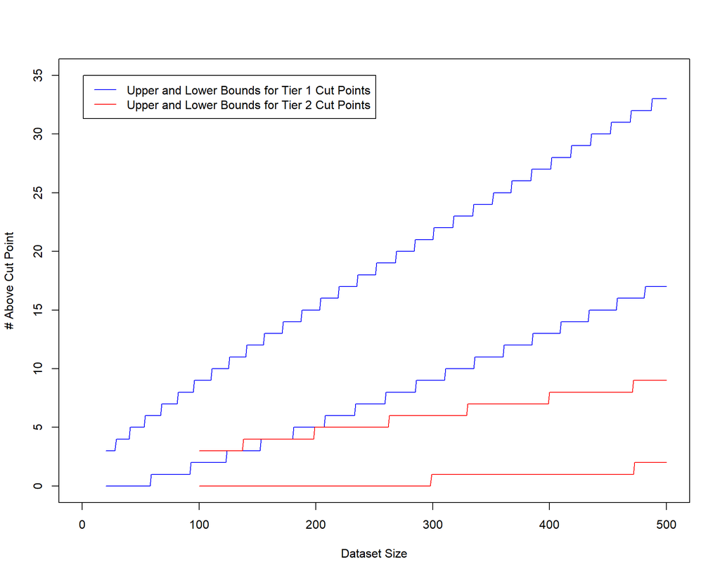

```r
plot(T1crit$size, T1crit$size-T1crit$upper, xlim=c(0, 500), ylim=c(0, 35),
     xlab="Dataset Size", ylab="# Above Cut Point", type="l", col="blue")
lines(T1crit$size, T1crit$size-T1crit$lower, lty=1, col="blue")

lines(T2crit$size, T2crit$size-T2crit$upper, lty=1, col="red")
lines(T2crit$size, T2crit$size-T2crit$lower, lty=1, col="red")

legend(1, 35, lty=c(1,1), col=c("blue","red"),
       legend=c("Upper and Lower Bounds for Tier 1 Cut Points",
                "Upper and Lower Bounds for Tier 2 Cut Points"))
```

Here are the codes to produce Fig 2:

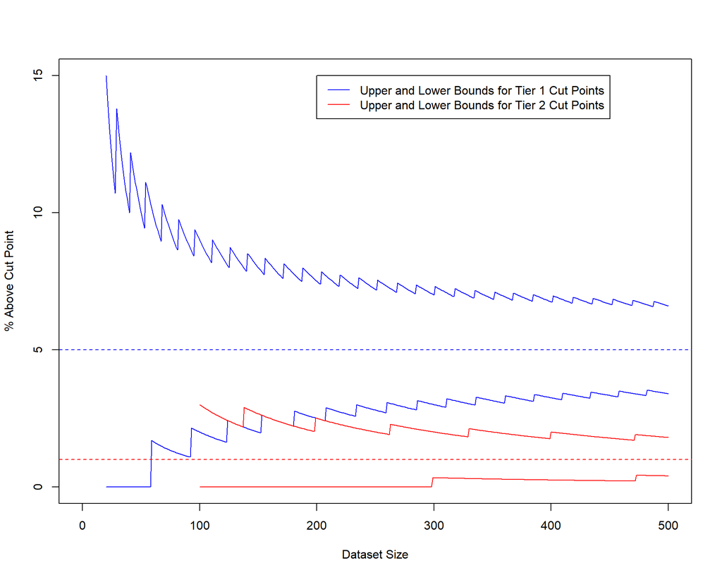

```r
plot(T1crit$size, T1crit$outupp*100, xlim=c(0, 500), ylim=c(0, 15),
     xlab="Dataset Size", ylab="% Above Cut Point", type="l", col="blue")
lines(T1crit$size, T1crit$outlow*100, lty=1, col="blue")
abline(h=5, lty=2, col="blue")

lines(T2crit$size, T2crit$outupp*100, lty=1, col="red")
lines(T2crit$size, T2crit$outlow*100, lty=1, col="red")
abline(h=1, lty=2, col="red")

legend(200, 15, lty=c(1,1), col=c("blue","red"),
       legend=c("Upper and Lower Bounds for Tier 1 Cut Points",
                "Upper and Lower Bounds for Tier 2 Cut Points"))
```

## Reference

Tan, Charles Y., Gregory S. Steeno, Zhiping You, Puneet Gaitonde, Chun-Hua Cai, John Kamerud, Boris Gorovits, and Daniel J. Baltrukonis. 2020. “Criteria to Reevaluate Anti-Drug Antibody Assay Cut Point Suitability in the Target Population.” Journal Article. *The AAPS Journal* 22 (2): 19. https://doi.org/10.1208/s12248-019-0400-4.